# 20190916

## 4.4 For-loops

The formula for the sum of the series 1+2+…+n is n(n+1)/2. Using what we learned about functions we can creat one that computes the Sn:

```r
compute_s_n <- function(n){
  x<-1:n
  sum(x)
}
```

n=1,…,25일때 Sm을 어떻게 계산할까? 이 때 for-loops를 사용한다.

```r
for(i in 1:5){
  print(i)
}
```

```
[1] 1
[1] 2
[1] 3
[1] 4
[1] 5
```

our Sn example:

```r
m <- 25
s_n <- vector(length = m)
for(n in 1:m){
  s_n[n] <- compute_s_n(n)
}
```

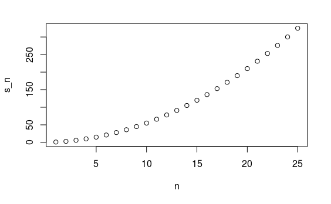

```r
n <- 1:m
plot(n,s_n)
```

```r
head(data.frame(s_n = s_n, formula = n*(n+1)/2))
```

|  | s_n | formula |
| --- | --- | --- |
| 1 | 1 | 1 |
| 2 | 3 | 3 |
| 3 | 6 | 6 |
| 4 | 10 | 10 |
| 5 | 15 | 15 |
| 6 | 21 | 21 |

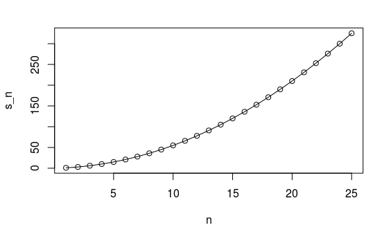

```r
plot(n, s_n)
lines(n,n*(n+1)/2)
```

## 4.5 Vectorization and functionals

*Vectorization* is preferred over for-loop since it results in shorter and clearer code. A vectorized function is a function that will apply the same operation on each of the vectors.

```r
x <- 1:10
sqrt(x)
```

```
 [1] 1.000000 1.414214 1.732051 2.000000 2.236068 2.449490 2.645751
 [8] 2.828427 3.000000 3.162278
```

```r
y <- 1:10
x*y
```

```
 [1]   1   4   9  16  25  36  49  64  81 100
```

This time, we don’t need for-loops.The function we just wrote,`compute_s_n`, does not work on each entry of `n`:

```r
n <- 1:25
compute_s_n(n)
```

```
numerical expression has 25 elements: only the first used
```

```
[1] 1
```

Functionals are functions which can apply the same function to each entry in all type of data. For numeric, logical, and character vector: `sapply`

The funtion `sapply` can do element-wise operation.

```r
x <- 1:10
sapply(x,sqrt)
```

```
 [1] 1.000000 1.414214 1.732051 2.000000 2.236068 2.449490 2.645751
 [8] 2.828427 3.000000 3.162278
```

This result is a vector of same length as the original `x`.

The for-loop above can be written:

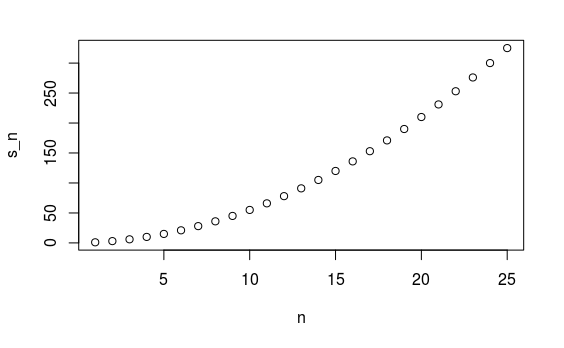

```r
n <- 1:25
s_n <- sapply(n,compute_s_n)
plot(n,s_n)
```

Other functials are `apply`, `lapply`, `tapply`, `mapply`, `vapply`, and `replicate`.

## 4.6 Exercises

1. What will this conditional expression return?

```r
x <- c(1,2,-3,4)

if(all(x>0)){
  print("All Postives")
} else{
  print("Not all positives")
}
```

```
[1] "Not all positives"
```

2. Which of the following expressions is always `FALSE` when at least one entry of a logical vector `x` is TRUE?

```r
x <- c(TRUE, TRUE, TRUE)

all(!x)
```

```
[1] FALSE
```

A. all(x)

B. any(x)

C. any(!x)

**D. all(!x)**

3. The function `nchar` tells you how many characters long a character vector is.

Write a line of code that assigns to the object `new_names` the state abbreviation when the state name is longer than 8 characters.

```r
dslabs::murders
```

| state | abb | region | population | total |
| --- | --- | --- | --- | --- |
| Alabama | AL | South | 4779736 | 135 |
| Alaska | AK | West | 710231 | 19 |
| Arizona | AZ | West | 6392017 | 232 |
| Arkansas | AR | South | 2915918 | 93 |
| California | CA | West | 37253956 | 1257 |
| Colorado | CO | West | 5029196 | 65 |
| Connecticut | CT | Northeast | 3574097 | 97 |
| Delaware | DE | South | 897934 | 38 |
| District of Columbia | DC | South | 601723 | 99 |
| Florida | FL | South | 19687653 | 669 |

[output cut: 41 more lines]

```r
data(murders)
new_names <- ifelse(((nchar(murders$state)) > 8), murders$abb, murders$state)
new_names
```

```
 [1] "Alabama"  "Alaska"   "Arizona"  "Arkansas" "CA"       "Colorado"
 [7] "CT"       "Delaware" "DC"       "Florida"  "Georgia"  "Hawaii"
[13] "Idaho"    "Illinois" "Indiana"  "Iowa"     "Kansas"   "Kentucky"
[19] "LA"       "Maine"    "Maryland" "MA"       "Michigan" "MN"
[25] "MS"       "Missouri" "Montana"  "Nebraska" "Nevada"   "NH"
[31] "NJ"       "NM"       "New York" "NC"       "ND"       "Ohio"
[37] "Oklahoma" "Oregon"   "PA"       "RI"       "SC"       "SD"
[43] "TN"       "Texas"    "Utah"     "Vermont"  "Virginia" "WA"
[49] "WV"       "WI"       "Wyoming"
```

4. Create a function `sum_n` that for any given value, say n, computes the sum of the integers from 1 to n (inclusive). Use the function to determine the sum of integers from 1 to 5,000.

```r
sum_n <- function(n){
  sum(1:n)
}
sum_n(5000)
```

```
[1] 12502500
```

5. Create a function `altman_plot` that takes two arguments, `x` and `y`, and plots the difference against the sum.

```r
altman_plot <- function(x){
  x
  y <- sum(x)
  plot(x,y)
}
altman_plot(x)
```

```
Error in xy.coords(x, y, xlabel, ylabel, log) :
  'x' and 'y' lengths differ
```

??? 해당 plot이 무엇을 보고자 하는지 조차 이해되지 않았으며 function을 지정했지만 length가 달라 실행되지 않는다.

6. After running the code below, what is the value of `x`?

```r
x <- 3
my_func <- function(y){
  x <- 5
  y+5
}
x
```

```
[1] 3
```

7. Write a function `compute_s_n` that for any given n computes the sum Sn = 1^2 + 2^2 + 3^2 +…n^2.Report the value of the sum when n=10.

```r
compute_s_n <- function(n){
  x <- 1:n
  sum(x^2)
}
compute_s_n(10)
```

```
[1] 385
```

8. Define an empty numerical vector `s_n` of size 25 using `s_n <- vector("numeric", 25)` and store in the results of S1,S2,…S25 using a for-loop.

```r
m <- 25
s_n <- vector("numeric", 25)
for(n in 1:m){
  s_n[n] <- compute_s_n(n)
}
```

9. Repeat exercise 8, but this time use `sapply`.

```r
n <- 1:25
sapply(n,compute_s_n)
```

```
 [1]    1    5   14   30   55   91  140  204  285  385  506  650  819
[14] 1015 1240 1496 1785 2109 2470 2870 3311 3795 4324 4900 5525
```

10. Repeat exercise 8, but this time use `map_dbl.`

```r
library(purrr)
map_dbl(n,compute_s_n)
```

```
 [1]    1    5   14   30   55   91  140  204  285  385  506  650  819
[14] 1015 1240 1496 1785 2109 2470 2870 3311 3795 4324 4900 5525
```

11. Plot Sn versus n. Use points defined by n = 1,…,25.

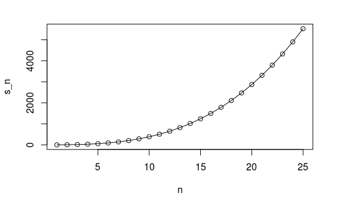

```r
n <- 1:25
plot(n,s_n)
lines(n,s_n)
```

12. Confirm that the formular for this sum is Sn =n(n+1)(2n+1)/6

```r
new_func <- function(n){
  p <- n*(n+1)*(2*n+1)/6
  p
}
sapply(n,compute_s_n)
```

[output not shown]

```r
sapply(n,new_func)
```

```
 [1]    1    5   14   30   55   91  140  204  285  385  506  650  819
[14] 1015 1240 1496 1785 2109 2470 2870 3311 3795 4324 4900 5525
```

logical적으로 일치함을 TRUE로 나타낼 수 있다면 좋을 것 같지만 성공하지 못했다.

This is the last of chapter 4.